# 2.1.1 A549 LOY vs sgCTRL — RNA-seq base analysis

## 11.3 Volcano

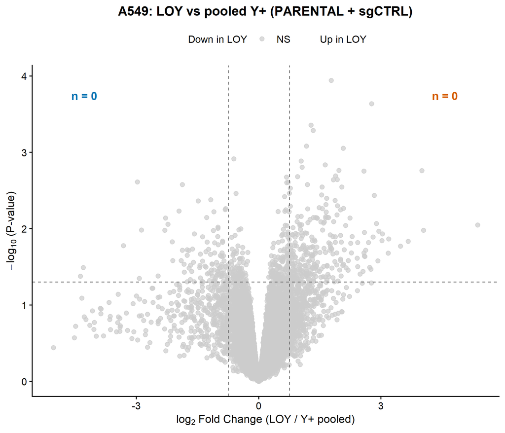

```
## Saved: volcano_LOY_v_pooled.(png|pdf)  [7x6 in]
```

## 11.4 fgsea (basic collections)

```
## Pooled ranks: 14620 genes (after RPS/RPL filter)
```

```
## Running fgsea (basic collections) for LOY vs pooled Y+...
```

```
##   Running hallmark (50 gene sets)...
##   Running reactome (1787 gene sets)...
##   Running kegg (186 gene sets)...
##   Running go_bp (7583 gene sets)...
```

LOY vs pooled Y+ — Significant pathways by collection

| collection | total | sig_up | sig_down |
| --- | --- | --- | --- |
| go_bp | 3638 | 31 | 167 |
| hallmark | 50 | 3 | 23 |
| kegg | 161 | 9 | 22 |
| reactome | 1001 | 13 | 158 |

## 11.5 GSEA dotplot (pooled)

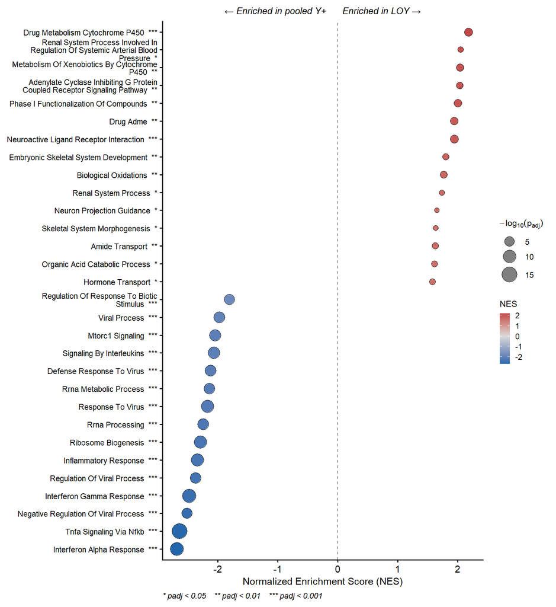

```
## Saved: gsea_dotplot_pooled.(png|pdf)  [5.5x6 in]
```

## 11.6 Hit concordance: paired sgCTRL vs pooled Y+

How well do the two contrasts agree? If the sgRNA control behaves like the parental, the pooled contrast should sharpen the statistics without changing the qualitative picture.

```
## Paired LOY-vs-sgCTRL DEGs:  0
```

```
## Pooled LOY-vs-Y+ DEGs:      0
```

```
## Intersection:                0
```

```
## Paired-only:                 0
```

```
## Pooled-only:                 0
```

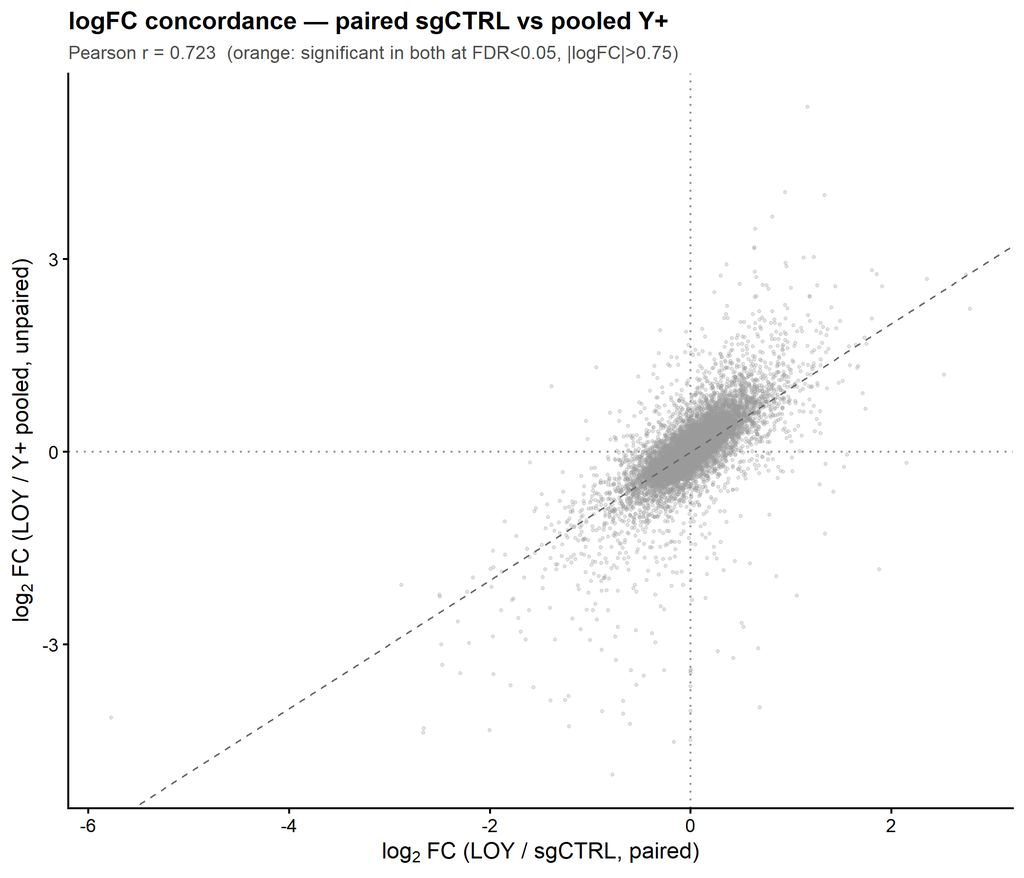

```
## Saved: concordance_paired_v_pooled.(png|pdf)  [7x6 in]
```

## 11.7 All-significant-pathways dotplot (no top-N cap)

Complement to §11.5: instead of the top-15-per-direction view, this shows **every** pathway across all four collections (Hallmark, Reactome, KEGG, GO:BP) that reaches `padj < 0.05` in the pooled contrast. With ~9,600 tested gene sets, this surfaces the full enrichment landscape — useful for spotting secondary signals the top-30 cut hides.

The helpers defined here are reused below for PRC2 (§11.8) and for the PARENTAL-vs-sgCTRL section (§12).

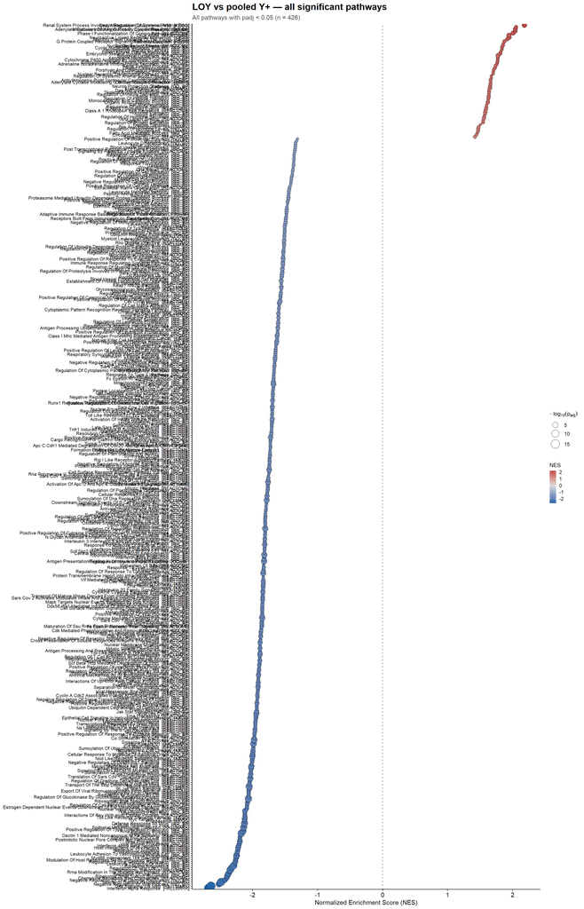

```
## Saved: gsea_all_sig_pooled.(png|pdf)  [9x14 in]
```

## 11.8 PRC2 / H3K27me3 pathway check (pooled)

Targeted view: pathways with `PRC2`, `H3K27`, `EZH2`, `EED`, `SUZ12`, or `POLYCOMB` in the name. These test whether the pooled contrast carries the same Polycomb-axis signal that the canonical sgCTRL contrast surfaces in §7 (albeit on the basic, not the expanded CGP, collections).

```
## PRC2 / H3K27me3-related pathways tested: 1 (significant at padj < 0.05: 0)
```

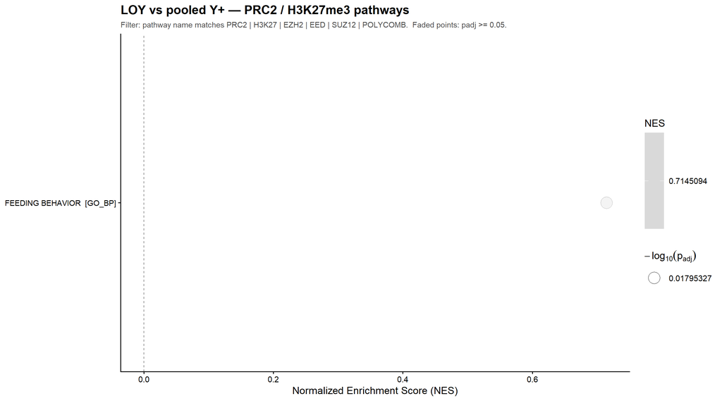

```
## Saved: gsea_prc2_pooled.(png|pdf)  [9x5 in]
```

## 11.9 TF activity panel (DoRothEA + decoupleR) — pooled

The same TF infrastructure used in §9 (DoRothEA A/B/C regulons + decoupleR CollecTRI network), but applied to the pooled-contrast t-statistics. Helper functions defined here are reused in §12 and §13.

```
## DoRothEA fgsea (pooled): 240 TFs tested, 20 significant (padj<0.05)
```

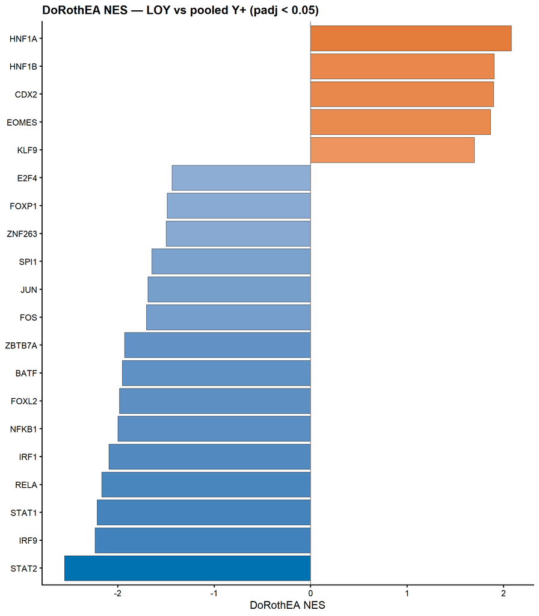

```
## Saved: tf_dorothea_bar_LOY_v_pooled.(png|pdf)  [7x8 in]
```

## 11.10 decoupleR contrast-level TF activity — pooled

```
## decoupleR contrast ULM (pooled): 669 TFs scored, 98 at p<0.05
```

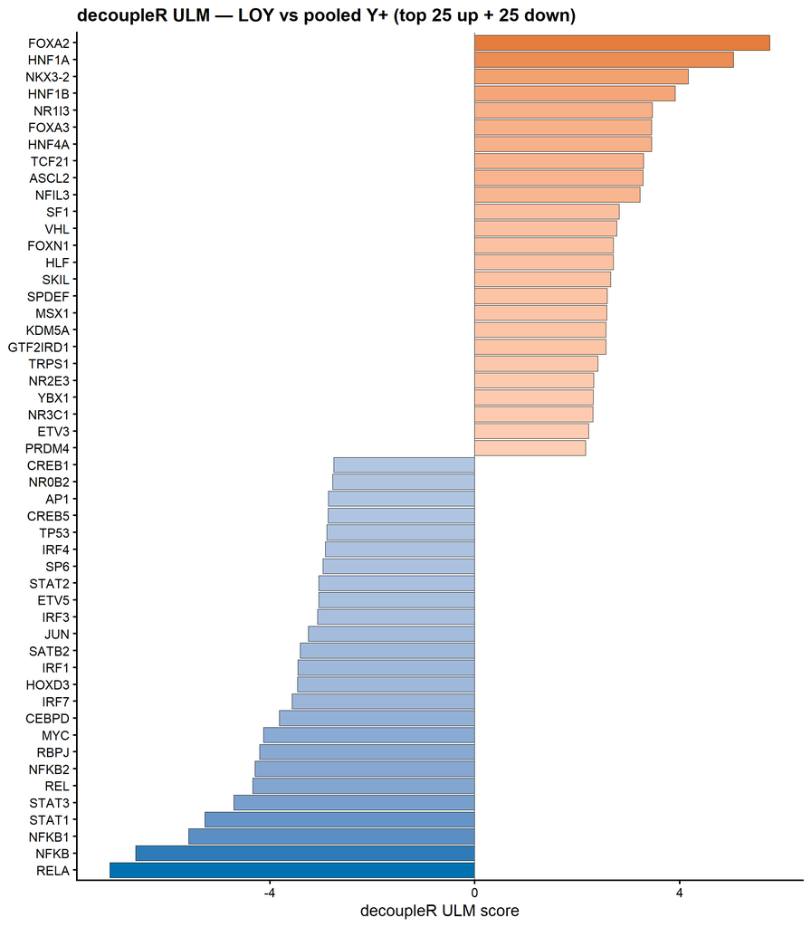

```
## Saved: decouple_TF_barplot_LOY_v_pooled.(png|pdf)  [7x8 in]
```

```
## decoupleR ULM TRRUST (pooled): 258 TFs scored, 35 at p<0.05
```

# 12. PARENTAL vs sgCTRL (sgRNA-control sanity check)

This contrast tests whether the **sgRNA control itself perturbs expression** relative to the unmodified parental population. A clean sgCTRL behaves like PARENTAL — few or no DEGs, no enriched programs — and that’s the assumption underlying §11’s pooled design. If this section produces many hits, the pooled-control analysis (§11) should be interpreted with caution and the §4 paired sgCTRL contrast remains the more conservative choice.

## 12.1 Setup

```
## Removing 9 chrY (MSY) genes
```

```
## Dropping 1 sample(s) to balance the paired PARENTAL-vs-CTRL design: A549-CTRL-4
```

```
## PARENTAL-vs-CTRL working set: 6 samples (PARENTAL / CTRL)
```

## 12.2 DE: paired (treatment + passage)

```
##
## sgCTRL vs PARENTAL: 14730 genes tested
```

```
##   FDR < 0.05:              318
```

[output not shown]

## 12.3 Volcano

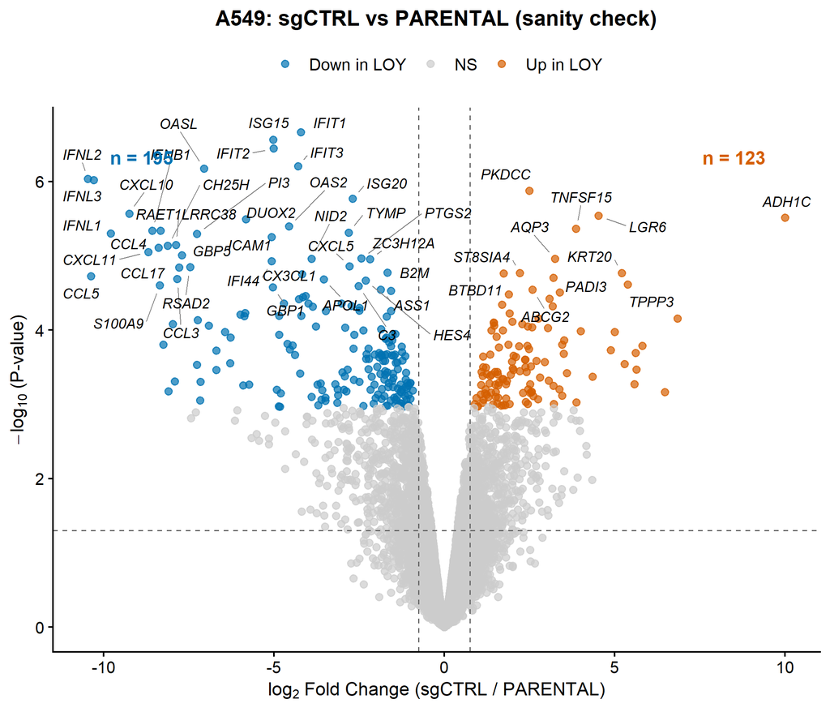

```
## Saved: volcano_sgCTRL_v_PARENTAL.(png|pdf)  [7x6 in]
```

## 12.4 fgsea + dotplot (top 30)

```
## sgCTRL-vs-PARENTAL ranks: 14620 genes (after RPS/RPL filter)
```

```
## Running fgsea for sgCTRL vs PARENTAL...
```

```
##   Running hallmark (50 gene sets)...
##   Running reactome (1787 gene sets)...
##   Running kegg (186 gene sets)...
##   Running go_bp (7583 gene sets)...
```

sgCTRL vs PARENTAL — Significant pathways by collection

| collection | total | sig_up | sig_down |
| --- | --- | --- | --- |
| go_bp | 3638 | 37 | 530 |
| hallmark | 50 | 0 | 22 |
| kegg | 161 | 9 | 29 |
| reactome | 1001 | 13 | 64 |

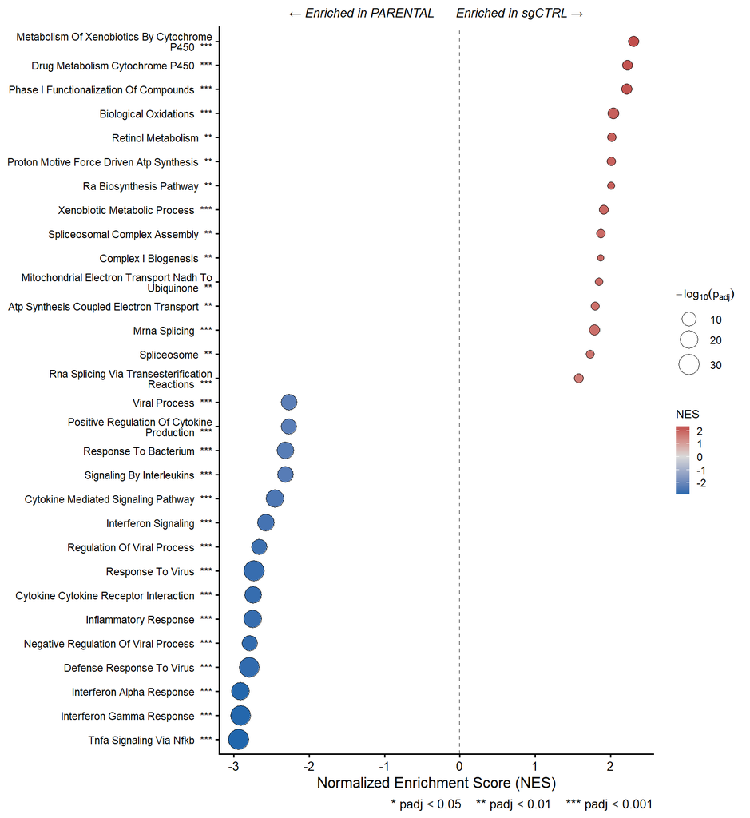

```
## Saved: gsea_dotplot_sgCTRL_v_PARENTAL.(png|pdf)  [5.5x6 in]
```

## 12.5 All-significant-pathways dotplot

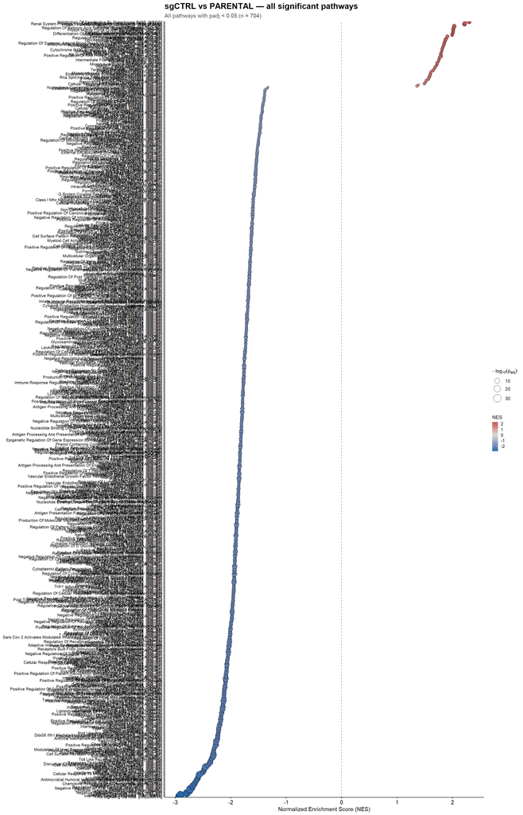

```
## Saved: gsea_all_sig_sgCTRL_v_PARENTAL.(png|pdf)  [9x14 in]
```

## 12.6 PRC2 / H3K27me3 pathway check

Critical sanity check: if PRC2-axis pathways move between PARENTAL and sgCTRL, the LOY-vs-sgCTRL Polycomb story in §7 is partly confounded by the sgRNA treatment itself. We expect NO significant PRC2 enrichment here.

```
## PRC2 / H3K27me3-related pathways tested: 1 (significant at padj < 0.05: 0)
```

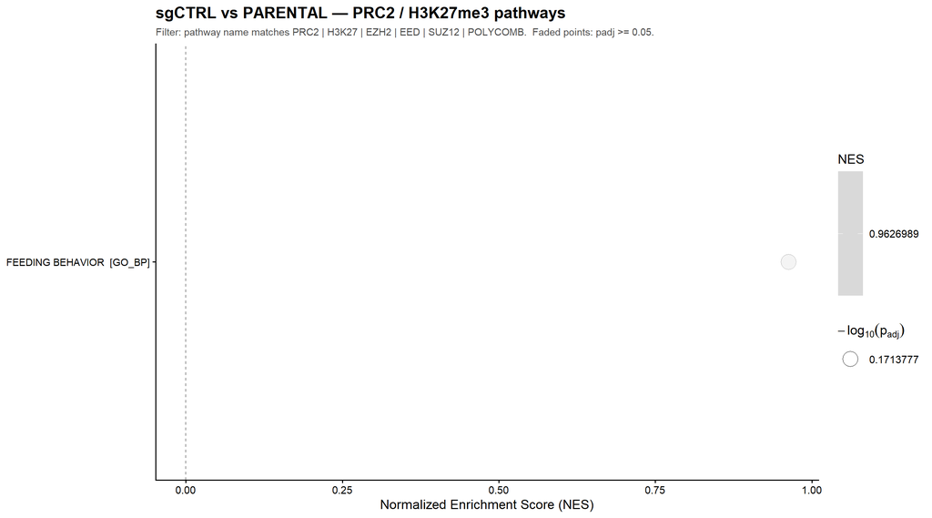

```
## Saved: gsea_prc2_sgCTRL_v_PARENTAL.(png|pdf)  [9x5 in]
```

## 12.7 TF activity panel (DoRothEA) — sgCTRL vs PARENTAL

```
## DoRothEA fgsea (sgCTRL vs PARENTAL): 240 TFs tested, 22 significant (padj<0.05)
```

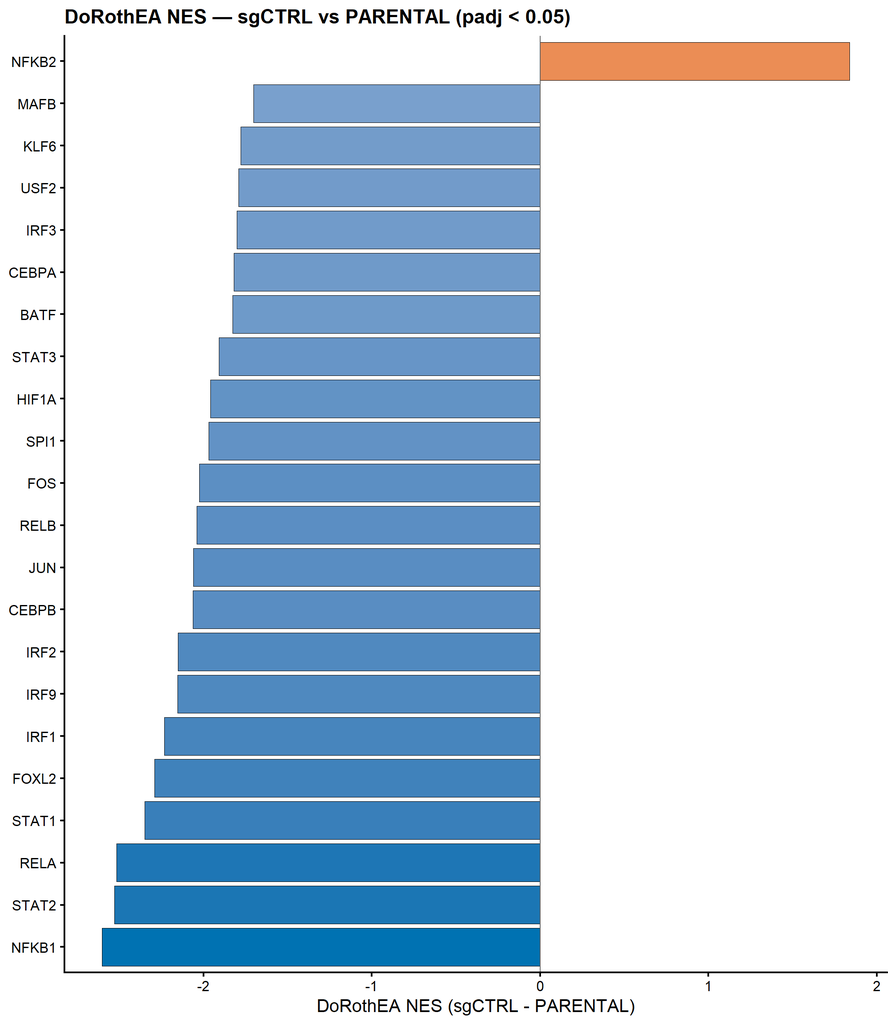

```
## Saved: tf_dorothea_bar_sgCTRL_v_PARENTAL.(png|pdf)  [7x8 in]
```

## 12.8 decoupleR contrast-level TF activity — sgCTRL vs PARENTAL

```
## decoupleR contrast ULM (sgCTRL vs PARENTAL): 669 TFs scored, 176 at p<0.05
```

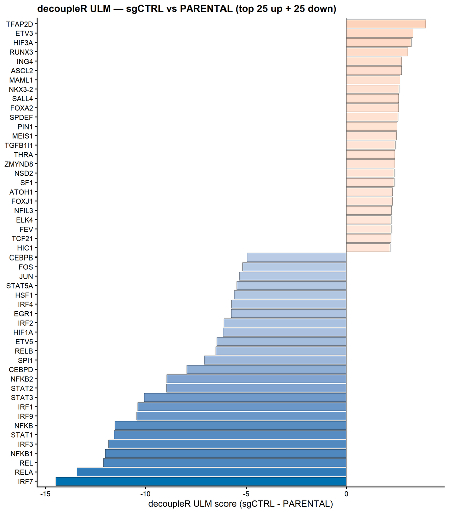

```
## Saved: decouple_TF_barplot_sgCTRL_v_PARENTAL.(png|pdf)  [7x8 in]
```

## 12.9 Verdict

[output not shown]

```
## sgCTRL vs PARENTAL significant pathways (padj<0.05): 704
```

```
## ...of which PRC2/H3K27 axis:                          0
```

```
## Significant TFs (DoRothEA, padj<0.05):                22
```

```
## Significant TFs (decoupleR contrast, p<0.05):         176
```

```
## VERDICT:
## MIXED: some non-PRC2 perturbation in sgCTRL. Pooled contrast still informative for power; trust convergent signal between §4 and §11.
```

# 13. LOY vs PARENTAL (alternative baseline)

A third LOY contrast, run against the unmodified parental population instead of against the matched sgRNA control. Concept: §4 asks “does LOY differ from a non-targeting sgRNA?”, §11 asks “does LOY differ from a Y+ baseline pooled across PARENTAL + sgCTRL?”, and this section asks “does LOY differ from the untouched parental cells?”. Convergence across these baselines flags LOY-driven biology that’s robust to control choice; divergence between this and §4 (when §12 is non-quiet) localizes how much of the §4 signal comes from sgRNA-itself effects vs. true LOY perturbation.

## 13.1 Setup

```
## Removing 9 chrY (MSY) genes
```

```
## Auto-balance: dropping 1 sample(s) in passages without both treatments
```

```
## LOY-vs-PARENTAL working set: 6 samples (PARENTAL / LOY)
```

## 13.2 DE: paired (treatment + passage)

```
##
## LOY vs PARENTAL: 14730 genes tested
```

```
##   FDR < 0.05:              460
```

```
##   FDR < 0.05 & |logFC| > 0.75:  460 (up: 205, down: 255)
```

## 13.3 Volcano

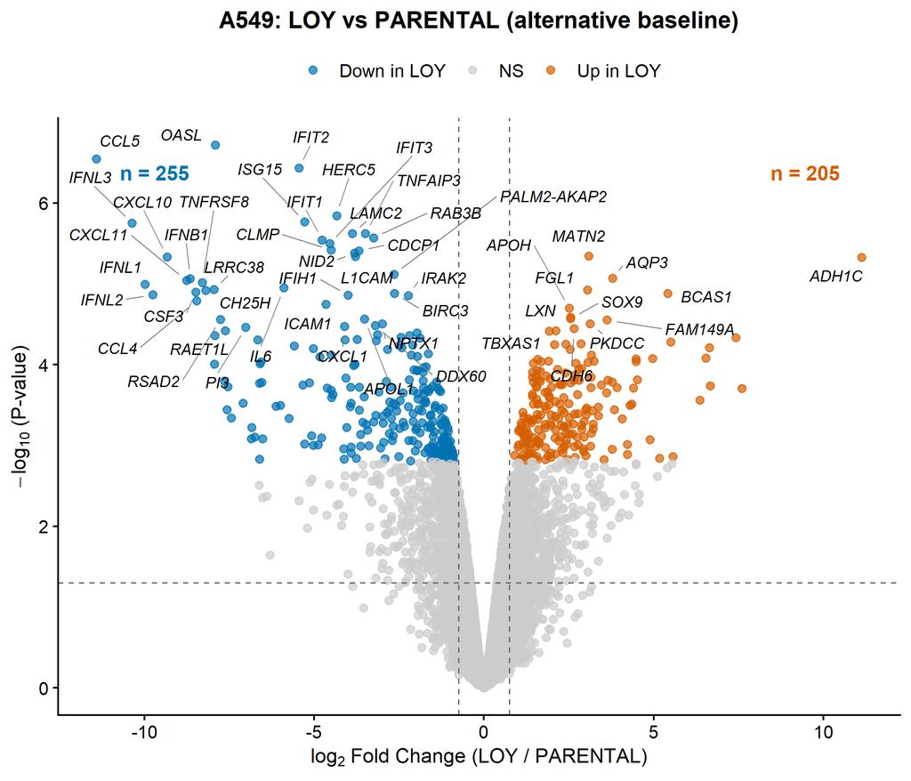

```
## Saved: volcano_LOY_v_PARENTAL.(png|pdf)  [7x6 in]
```

## 13.4 fgsea + dotplot (top 30)

```
## LOY-vs-PARENTAL ranks: 14620 genes (after RPS/RPL filter)
```

```
## Running fgsea for LOY vs PARENTAL...
```

```
##   Running hallmark (50 gene sets)...
##   Running reactome (1787 gene sets)...
##   Running kegg (186 gene sets)...
##   Running go_bp (7583 gene sets)...
```

LOY vs PARENTAL — Significant pathways by collection

| collection | total | sig_up | sig_down |
| --- | --- | --- | --- |
| go_bp | 3638 | 29 | 314 |
| hallmark | 50 | 2 | 21 |
| kegg | 161 | 5 | 21 |
| reactome | 1001 | 16 | 141 |

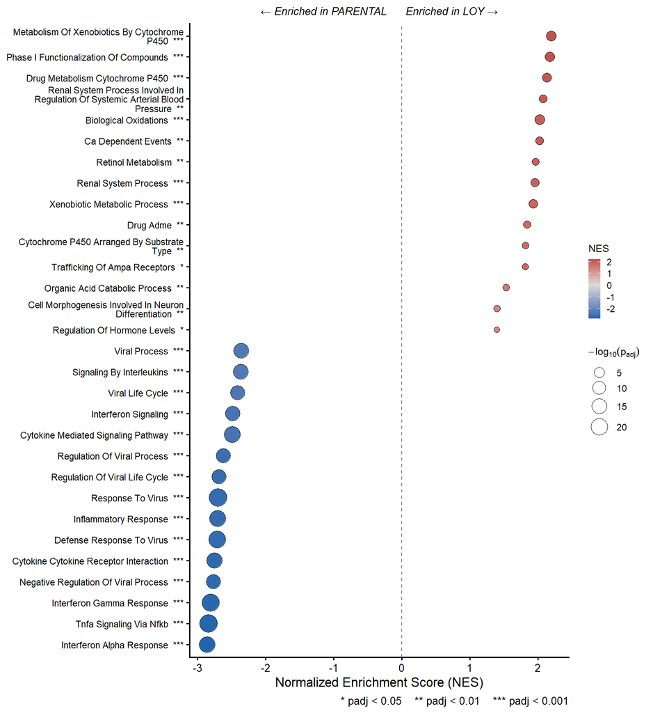

```
## Saved: gsea_dotplot_LOY_v_PARENTAL.(png|pdf)  [5.5x6 in]
```

## 13.5 All-significant-pathways dotplot

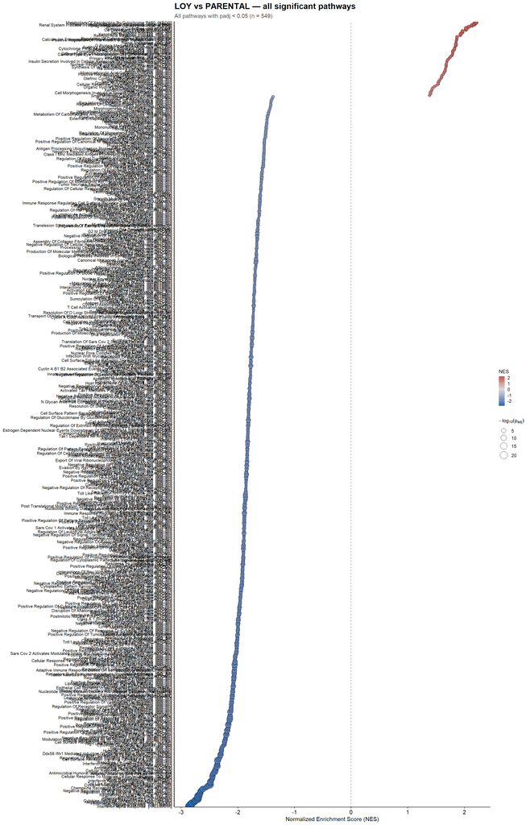

```
## Saved: gsea_all_sig_LOY_v_PARENTAL.(png|pdf)  [9x14 in]
```

## 13.6 PRC2 / H3K27me3 pathway check

Direct comparison against the parental untreated cells — if the Polycomb / H3K27me3 axis is the core LOY-driven program in §7, it should reappear here *with the same direction*. Convergence with §7 strengthens the chromatin-axis story.

```
## PRC2 / H3K27me3-related pathways tested: 1 (significant at padj < 0.05: 0)
```

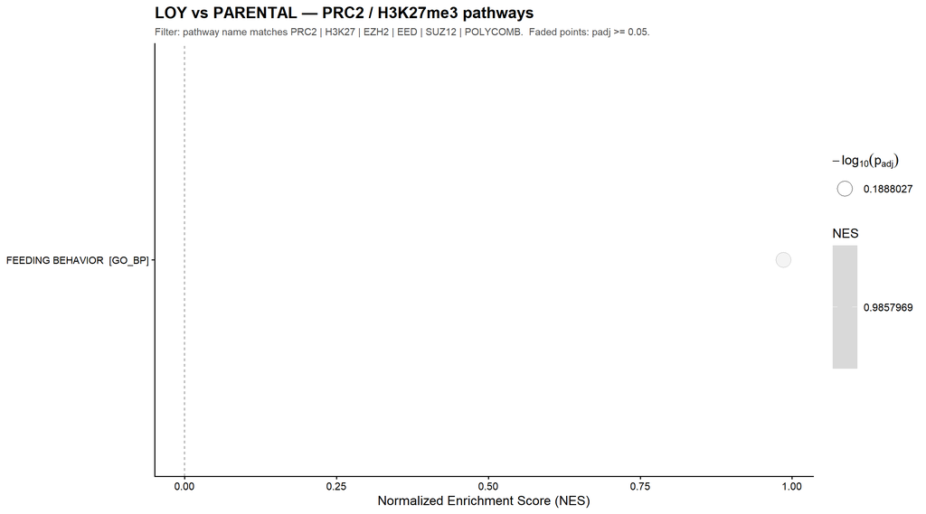

```
## Saved: gsea_prc2_LOY_v_PARENTAL.(png|pdf)  [9x5 in]
```

## 13.7 TF activity panel (DoRothEA) — LOY vs PARENTAL

```
## DoRothEA fgsea (LOY vs PARENTAL): 240 TFs tested, 28 significant (padj<0.05)
```

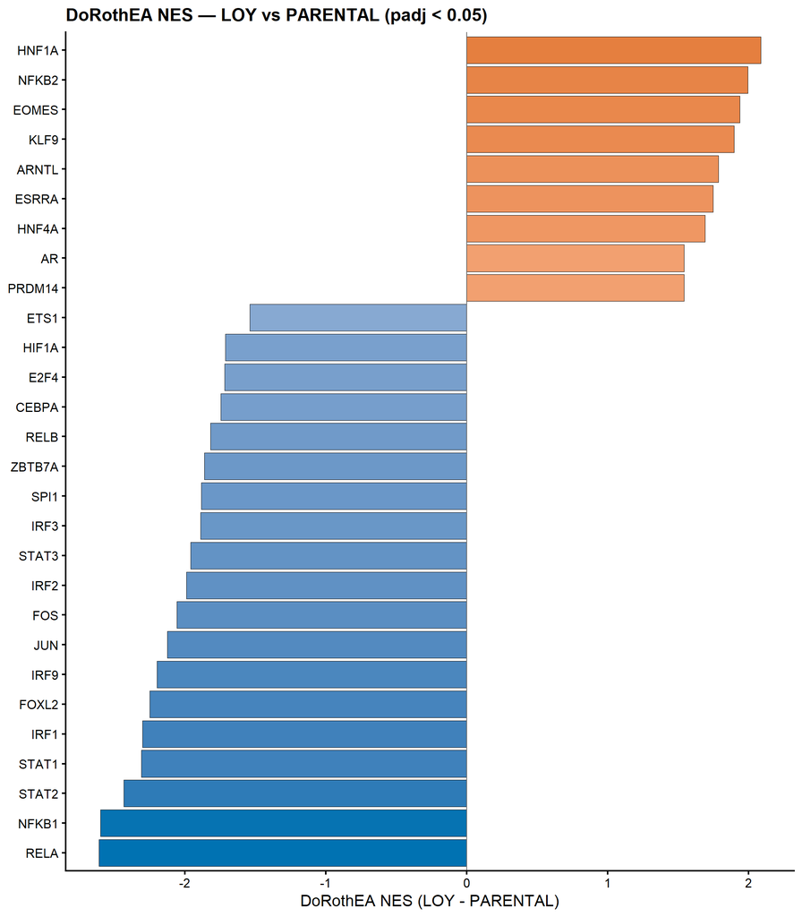

```
## Saved: tf_dorothea_bar_LOY_v_PARENTAL.(png|pdf)  [7x8 in]
```

## 13.8 decoupleR contrast-level TF activity — LOY vs PARENTAL

```
## decoupleR contrast ULM (LOY vs PARENTAL): 669 TFs scored, 171 at p<0.05
```

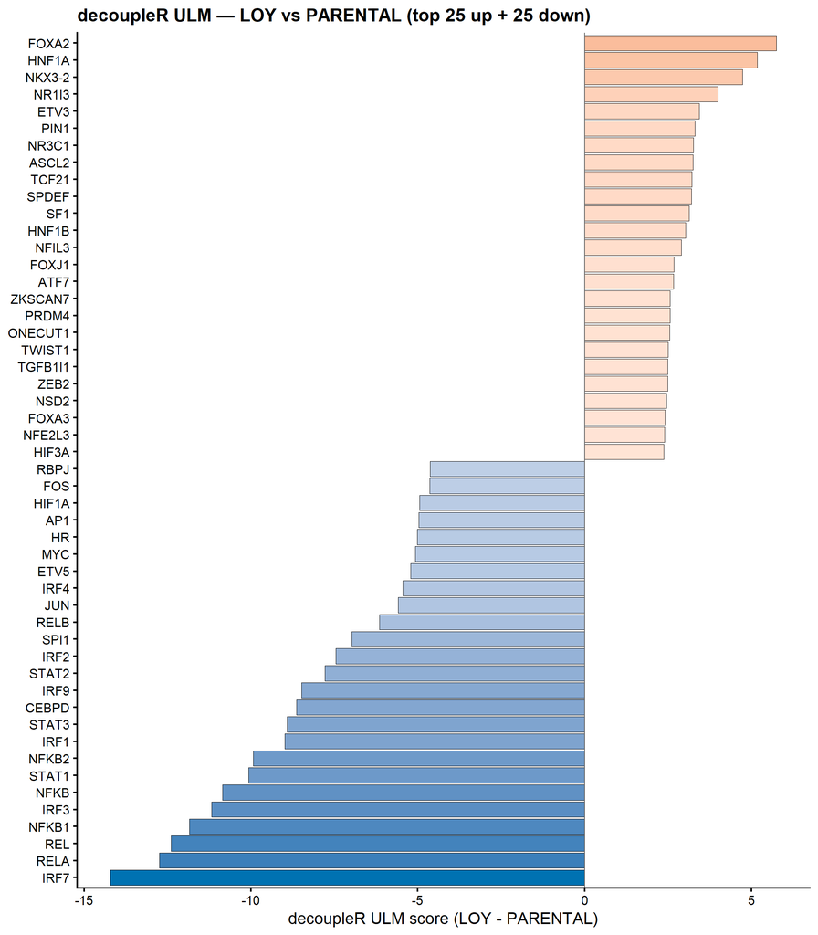

```
## Saved: decouple_TF_barplot_LOY_v_PARENTAL.(png|pdf)  [7x8 in]
```

## 13.9 Concordance with the canonical LOY-vs-sgCTRL contrast

Direct head-to-head: do the LOY-driven changes look the same whether we reference against PARENTAL or against sgCTRL? Strong concordance means the canonical §4 result is not driven by the sgRNA itself; weak concordance flags the §12 sgRNA-effect contamination as material.

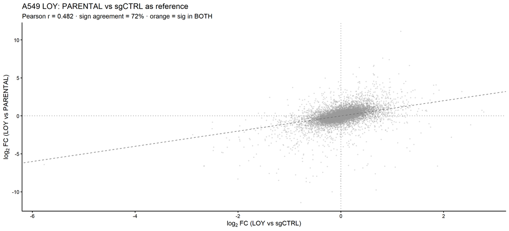

```
## Saved: concordance_LOY_vs_sgCTRL_vs_PARENTAL.(png|pdf)  [11x5 in]
```

```
## Shared genes: 14736   |   sig in BOTH: 0   |   logFC Pearson r = 0.482   |   sign agreement = 71.7%
```

## 13.10 Verdict

```
## LOY vs PARENTAL DEGs (FDR<0.05, |logFC|>0.75):       460
```

```
## LOY vs PARENTAL significant pathways (padj<0.05): 549
```

```
## ...of which PRC2/H3K27 axis:                       0
```

```
## Significant TFs (DoRothEA, padj<0.05):             28
```

```
## Significant TFs (decoupleR contrast, p<0.05):      171
```

```
## VERDICT:
## PARTIAL: moderate logFC agreement between baselines. Some §4 signal may include sgRNA-vs-PARENTAL drift; cross-reference §12's verdict.
```

# 14. msVIPER master-regulator analysis

Master-regulator inference via **msVIPER** (Alvarez et al., 2016) on the LOY-vs-sgCTRL, LOY-vs-pooled, and sgCTRL-vs-PARENTAL contrasts. Four regulon sources are run side-by-side on the two LOY contrasts (and the canonical CollecTRI/ARACNe pair on the sgRNA sanity-check contrast):

1. **CollecTRI** (HGNC-keyed) — the same human regulome decoupleR uses (§9).
2. **TCGA-LUAD ARACNe** (Entrez-keyed; `aracne.networks::regulonluad`) — tissue-matched to A549 (lung adenocarcinoma).
3. **TRRUST v2** (HGNC-keyed; OmnipathR) — independently curated literature regulons; orthogonal to CollecTRI.
4. **MSigDB C3:TFT:GTRD** (HGNC-keyed; msigdbr) — ChIP-derived TF target gene sets; orthogonal to literature curation.

Point estimates only (no bootstrap, shadow, or synergy) to keep render time manageable. Outputs feed the cross-source consistency analysis in §15.

## 14.1 Regulons + helpers

```
## CollecTRI regulon: 1186 TFs (median target size 9)
```

```
## TCGA-LUAD ARACNe regulon (relabeled TF names to HGNC; targets remain Entrez): 4290 TFs (median target size 56)
```

```
## TRRUST v2 regulon: 742 TFs (median target size 3)
```

```
## MSigDB C3:TFT:GTRD regulon: 505 TFs (median target size 288)
```

```
## HGNC -> Entrez map: 14739 entries
```

## 14.2 LOY vs sgCTRL — canonical

### CollecTRI

```
## msVIPER CollecTRI (LOY vs sgCTRL): 269 TFs, 8 at FDR<0.05
```

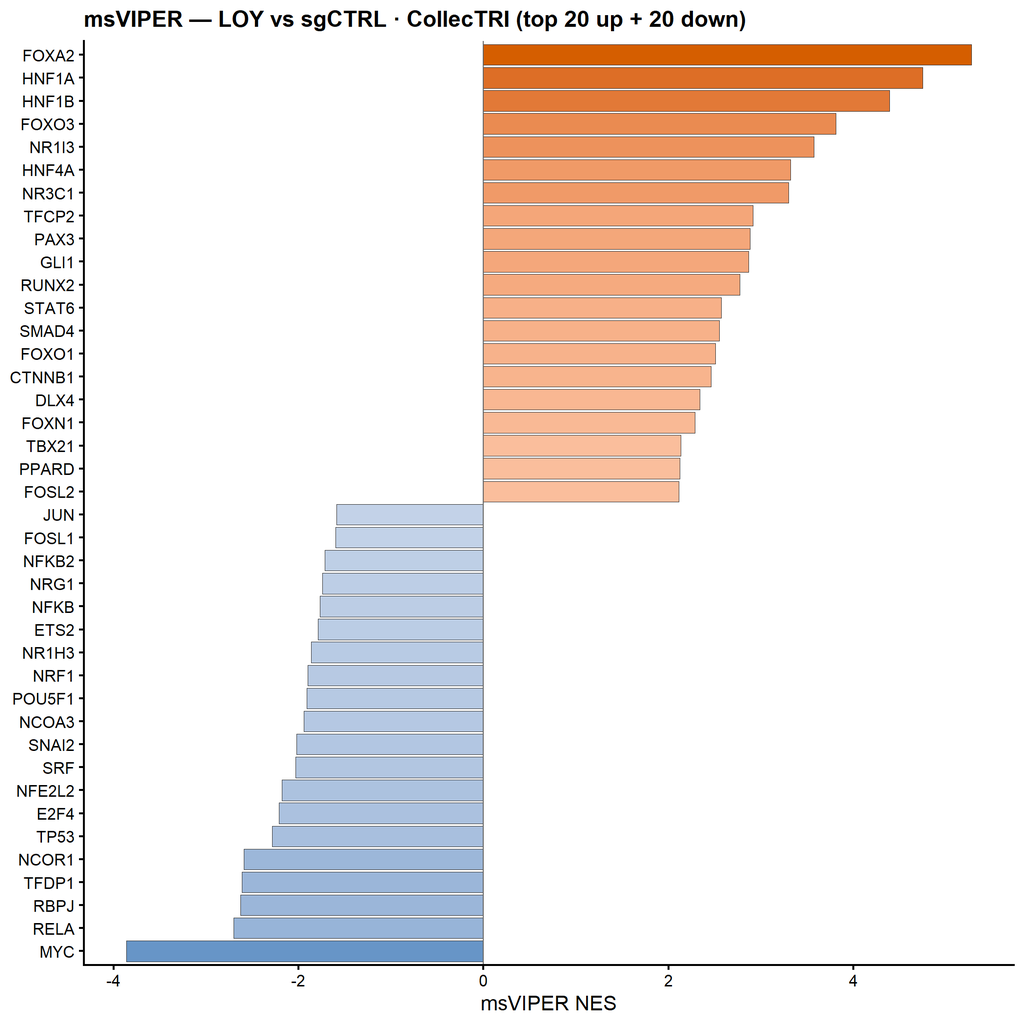

```
## Saved: msviper_bar_LOY_v_sgCTRL_collectri.(png|pdf)  [7x8 in]
```

### TCGA-LUAD ARACNe

```
## msVIPER ARACNe (LOY vs sgCTRL): 3246 TFs, 907 at FDR<0.05
```

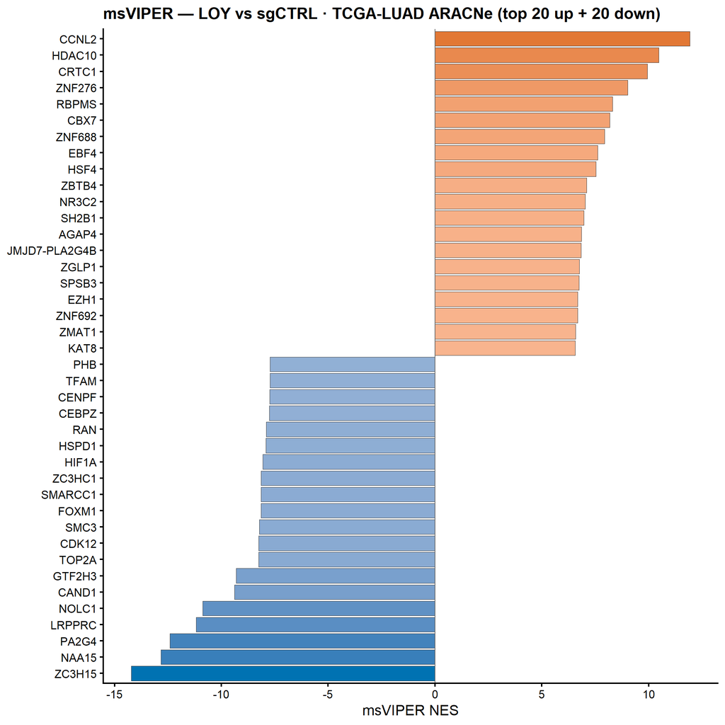

```
## Saved: msviper_bar_LOY_v_sgCTRL_aracne_luad.(png|pdf)  [7x8 in]
```

### TRRUST v2

```
## msVIPER TRRUST (LOY vs sgCTRL): 44 TFs, 2 at FDR<0.05
```

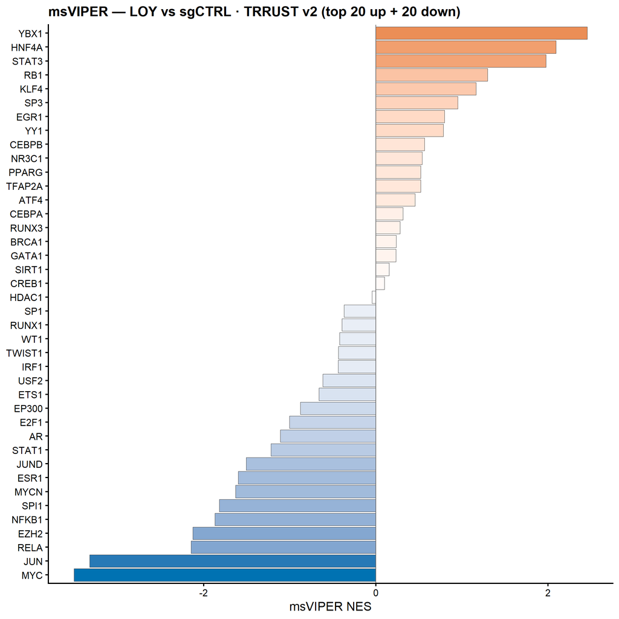

```
## Saved: msviper_bar_LOY_v_sgCTRL_trrust.(png|pdf)  [7x8 in]
```

### MSigDB C3:TFT:GTRD

```
## msVIPER MSigDB C3:TFT:GTRD (LOY vs sgCTRL): 399 TFs, 94 at FDR<0.05
```

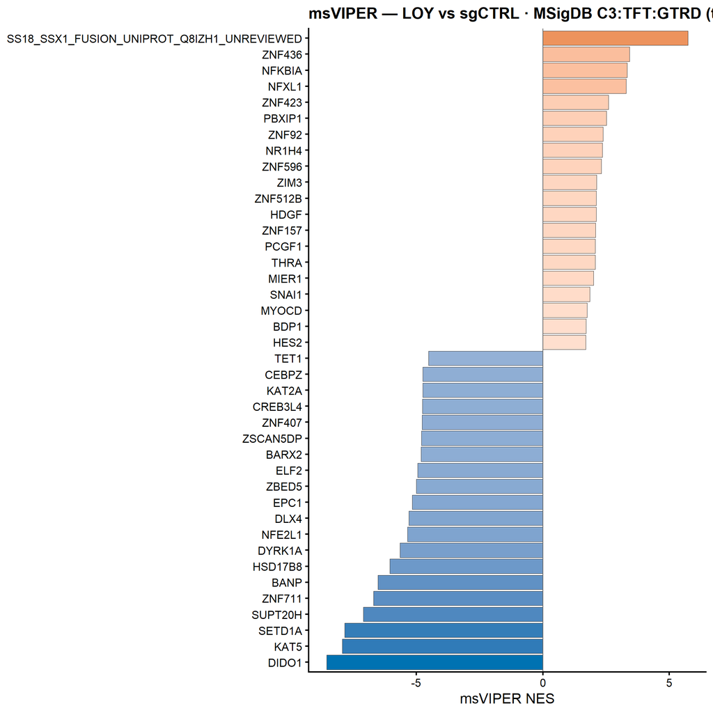

```
## Saved: msviper_bar_LOY_v_sgCTRL_msigdb_tft.(png|pdf)  [7x8 in]
```

## 14.3 LOY vs pooled Y+

### CollecTRI

```
## msVIPER CollecTRI (LOY vs pooled): 269 TFs, 14 at FDR<0.05
```

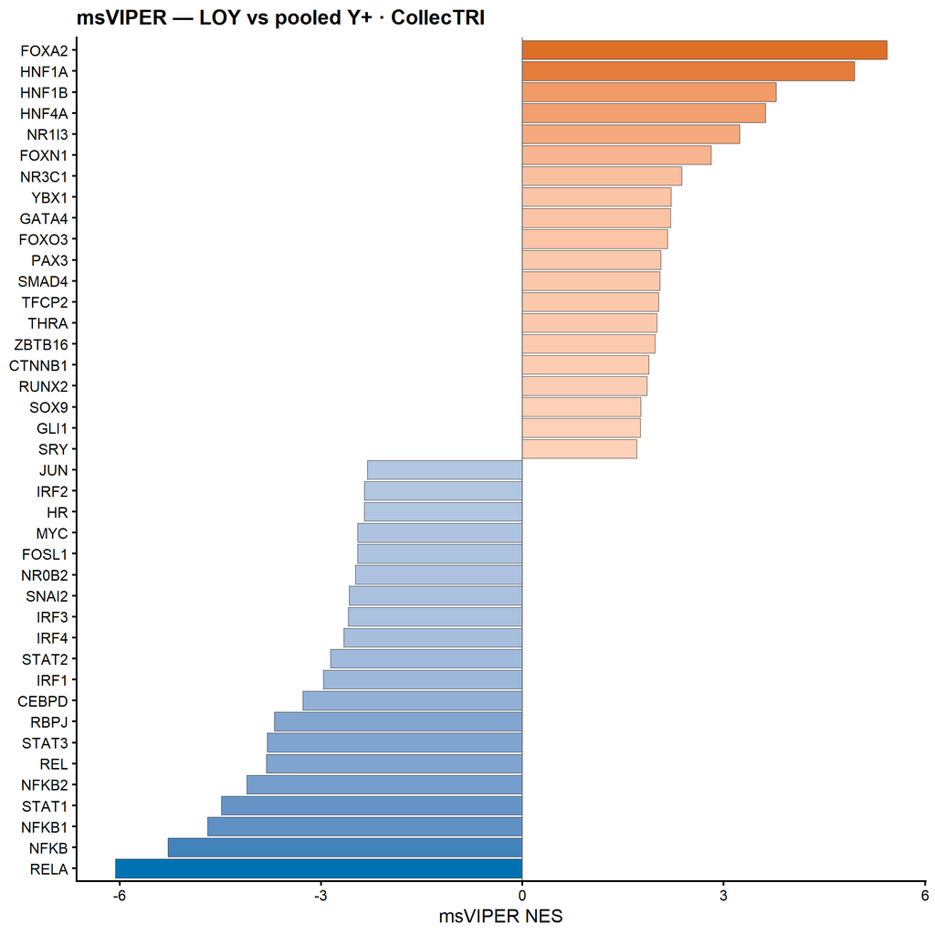

```
## Saved: msviper_bar_LOY_v_pooled_collectri.(png|pdf)  [7x8 in]
```

### TCGA-LUAD ARACNe

```
## msVIPER ARACNe (LOY vs pooled): 3246 TFs, 1225 at FDR<0.05
```

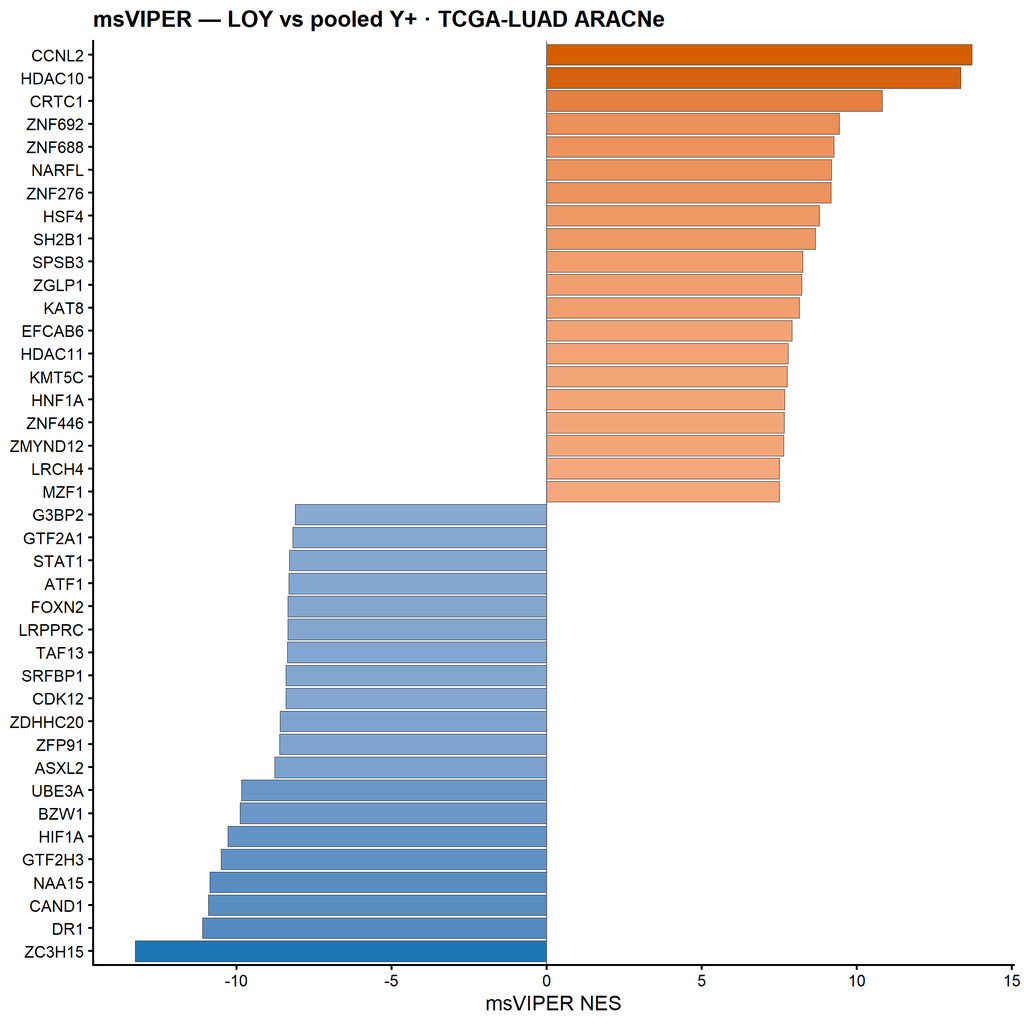

```
## Saved: msviper_bar_LOY_v_pooled_aracne_luad.(png|pdf)  [7x8 in]
```

### TRRUST v2

```
## msVIPER TRRUST (LOY vs pooled): 44 TFs, 3 at FDR<0.05
```

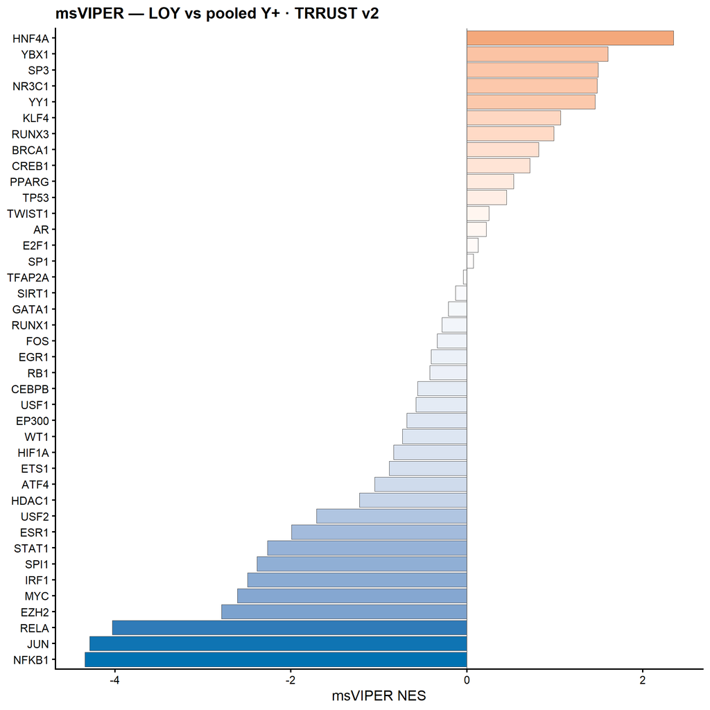

```
## Saved: msviper_bar_LOY_v_pooled_trrust.(png|pdf)  [7x8 in]
```

### MSigDB C3:TFT:GTRD

```
## msVIPER MSigDB C3:TFT:GTRD (LOY vs pooled): 399 TFs, 45 at FDR<0.05
```

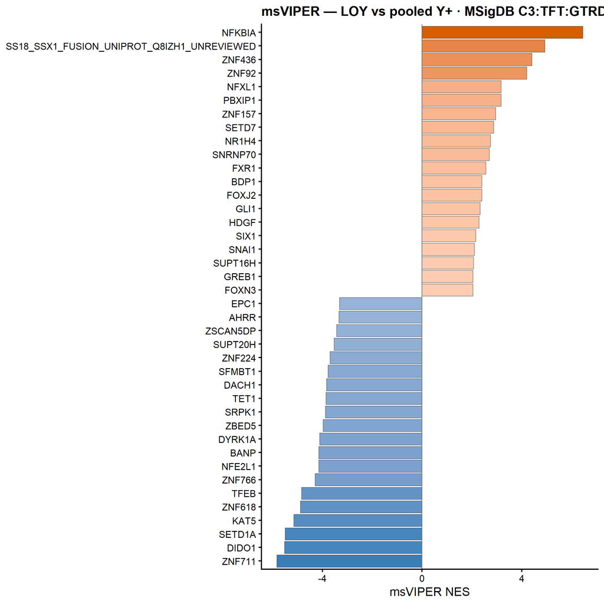

```
## Saved: msviper_bar_LOY_v_pooled_msigdb_tft.(png|pdf)  [7x8 in]
```

## 14.4 sgCTRL vs PARENTAL — sanity check

### CollecTRI

```
## msVIPER CollecTRI (sgCTRL vs PARENTAL): 269 TFs, 30 at FDR<0.05
```

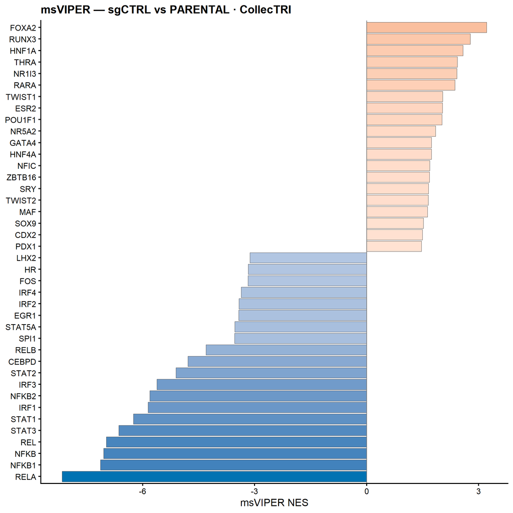

```
## Saved: msviper_bar_sgCTRL_v_PARENTAL_collectri.(png|pdf)  [7x8 in]
```

### TCGA-LUAD ARACNe

```
## msVIPER ARACNe (sgCTRL vs PARENTAL): 3246 TFs, 1240 at FDR<0.05
```

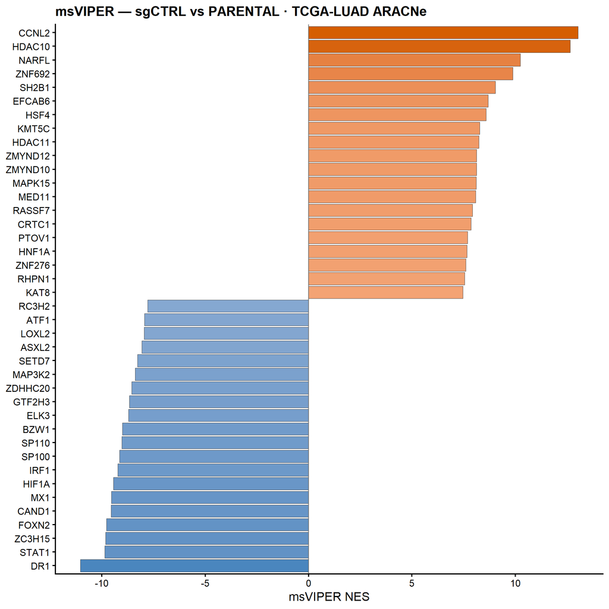

```
## Saved: msviper_bar_sgCTRL_v_PARENTAL_aracne_luad.(png|pdf)  [7x8 in]
```

# 15. Cross-source TF consistency

This section integrates **every TF result generated above**. The LOY-relevant axis now spans **seven methods** (DoRothEA fgsea, decoupleR ULM × {CollecTRI, TRRUST}, msVIPER × {CollecTRI, TCGA-LUAD ARACNe, TRRUST, MSigDB C3:TFT:GTRD}) over **two LOY contrasts** (canonical sgCTRL-paired + pooled Y+) = up to **14 NES values** per TF. The sgCTRL-vs-PARENTAL sanity check keeps its original four-method panel and is used only to filter out sgRNA-driven artifacts.

A TF that scores highly in BOTH LOY contrasts (canonical + pooled) across multiple methods, AND is silent in the sgCTRL-vs-PARENTAL sanity check, is a robust master-regulator candidate. Conversely, TFs that score highly only in the sgCTRL-vs-PARENTAL contrast are sgRNA artifacts to discount.

## 15.1 Aggregate all TF NES results

TF result counts by contrast × source

| contrast | source | tested | sig |
| --- | --- | --- | --- |
| LOY_v_pooled | DoRothEA | 240 | 20 |
| LOY_v_pooled | decoupleR_CollecTRI | 669 | 98 |
| LOY_v_pooled | decoupleR_TRRUST | 258 | 35 |
| LOY_v_pooled | msVIPER_ARACNe | 3246 | 1225 |
| LOY_v_pooled | msVIPER_CollecTRI | 269 | 14 |
| LOY_v_pooled | msVIPER_TFT | 399 | 45 |
| LOY_v_pooled | msVIPER_TRRUST | 44 | 3 |
| LOY_v_sgCTRL | DoRothEA | 240 | 4 |
| LOY_v_sgCTRL | decoupleR_CollecTRI | 669 | 107 |
| LOY_v_sgCTRL | decoupleR_TRRUST | 258 | 36 |
| LOY_v_sgCTRL | msVIPER_ARACNe | 3246 | 907 |
| LOY_v_sgCTRL | msVIPER_CollecTRI | 269 | 8 |
| LOY_v_sgCTRL | msVIPER_TFT | 399 | 94 |
| LOY_v_sgCTRL | msVIPER_TRRUST | 44 | 2 |
| sgCTRL_v_PARENTAL | DoRothEA | 240 | 22 |
| sgCTRL_v_PARENTAL | decoupleR_CollecTRI | 669 | 176 |
| sgCTRL_v_PARENTAL | msVIPER_ARACNe | 3246 | 1240 |
| sgCTRL_v_PARENTAL | msVIPER_CollecTRI | 269 | 30 |

## 15.2 Consistency heatmap (top robust TFs)

Score each TF by how many of the **two LOY-relevant** source × contrast combinations it reaches significance in (max = 14: 7 sources × 2 LOY contrasts). Heatmap the NES of the top scorers across all 14 cells.

```
## TFs significant in >=5 LOY-relevant source x contrast cells: 13 (showing top 13)
```

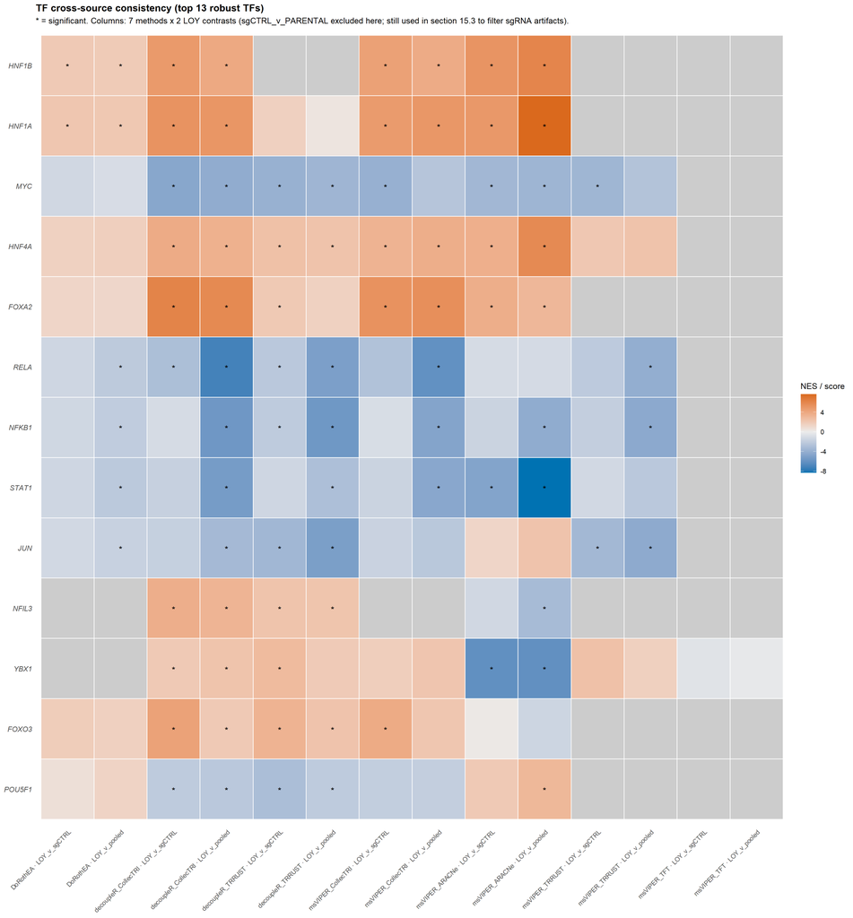

```
## Saved: tf_consistency_heatmap.(png|pdf)  [13x14 in]
```

## 15.3 Robust hits — TFs flagged by multiple sources in BOTH LOY contrasts and SILENT in sgCTRL-vs-PARENTAL

The cleanest robust hits: significant in BOTH LOY contrasts under at least **four of the seven methods** per contrast, NOT significant in sgCTRL-vs-PARENTAL (i.e., not an sgRNA artifact). Threshold scales with the larger panel — at the previous “≥2” cutoff, the 7-method panel would flag a TF supported by less than a third of sources.

```
## Robust LOY TFs (>=4 of 7 sources in both LOY contrasts, silent in sgCTRL_v_PARENTAL): 0
```

```
## No TF met the strict robust-hit criteria.
```

# 16. Label-permutation null

How much of what we see in §4–§15 is real biology vs. method-level noise? This section shuffles the **treatment labels** (LOY / sgCTRL / PARENTAL) across samples *N* times, re-runs the canonical pipeline on each shuffle (unpaired limma–voom DE on the LOY-vs-sgCTRL subset → Hallmark fgsea → decoupleR ULM TF activity on CollecTRI), and asks: **how often does a random labeling produce as many DEGs / enriched pathways / significant TFs as the real assignment?**

The DE design here is **unpaired** for both the observed reference value and the null — many shuffles place both LOY samples in the same passage and would otherwise yield rank-deficient paired designs. An unpaired null is the fair head-to-head and is generally more permissive (more variance to explain), so finding the real result extreme against it is conservative.

## 16.1 Setup

```
## N permutations: 100   |   class sizes preserved: CTRL=4, LOY=4, PARENTAL=3
```

## 16.2 Helpers

```
## Observed (unpaired, real labels):
```

```
##   N_DEG (FDR<0.05, |lfc|>0.75): 8
```

```
##   N_Hallmark (padj<0.05):   13
```

```
##   N_TF (CollecTRI ULM p<0.05): 95
```

## 16.3 Run permutations

```
## Permutation summary (median [10th–90th percentile]):
```

```
##   n_deg   :      0 [     0 -      0]
##   n_gsea  :     22 [    14 -     30]
##   n_tf    :     94 [    66 -    134]
```

## 16.4 Null vs observed histograms

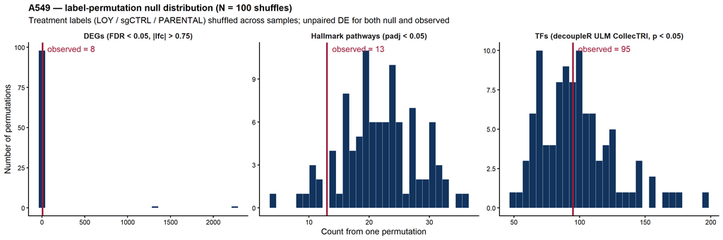

```
## Saved: permutation_null_histograms.(png|pdf)  [12x4 in]
```

## 16.5 Empirical p-values

Permutation-null summary for A549 (N = 100 shuffles)

| metric | observed | null_median | null_p10 | null_p90 | empirical_p_right |
| --- | --- | --- | --- | --- | --- |
| DEGs (FDR < 0.05, \|lfc\| > 0.75) | 8 | 0 | 0 | 0.0 | 0.030 |
| Hallmark pathways (padj < 0.05) | 13 | 22 | 14 | 30.0 | 0.921 |
| TFs (decoupleR ULM CollecTRI, p < 0.05) | 95 | 94 | 66 | 134.4 | 0.495 |

**How to read this:** the null distribution shows how many DEGs / pathways / TFs you’d typically recover from a random treatment labeling at the same sample sizes. An empirical p-value near 0 ( = real value far above the null) means the canonical analysis is producing signal well above what random relabeling generates. An empirical p near 1 would mean the real result is indistinguishable from random — i.e. the signal isn’t separable from method-level noise at this sample size.